# Analyzing the ToothGrowth data

AV-dev

### 1. Synopsis

This project analyses the Tooth Growth data in the R datasets package and tries to find the correlation between the dose of supplement and tooth length in guinea pigs.

### 1.1. Loading Data

```r
library(datasets)
library(ggplot2)

data<-ToothGrowth
head(data)
```

```
##    len supp dose
## 1  4.2   VC  0.5
## 2 11.5   VC  0.5
## 3  7.3   VC  0.5
## 4  5.8   VC  0.5
## 5  6.4   VC  0.5
## 6 10.0   VC  0.5
```

### 1.2. Data Summary

```r
summary(data)
```

```
##       len        supp         dose
##  Min.   : 4.20   OJ:30   Min.   :0.500
##  1st Qu.:13.07   VC:30   1st Qu.:0.500
##  Median :19.25           Median :1.000
##  Mean   :18.81           Mean   :1.167
##  3rd Qu.:25.27           3rd Qu.:2.000
##  Max.   :33.90           Max.   :2.000
```

### 1.3. Exploring the data

```r
# Count any missing values
sum(is.na(data))
```

```
## [1] 0
```

Finding all unique values

```r
unique(data$supp)
```

```
## [1] VC OJ
## Levels: OJ VC
```

```r
unique(data$dose)
```

```
## [1] 0.5 1.0 2.0
```

Checking How the suppliment type and Dose are distributed in the datasets.

```r
table(data$dose,data$supp)
```

```
##
##       OJ VC
##   0.5 10 10
##   1   10 10
##   2   10 10
```

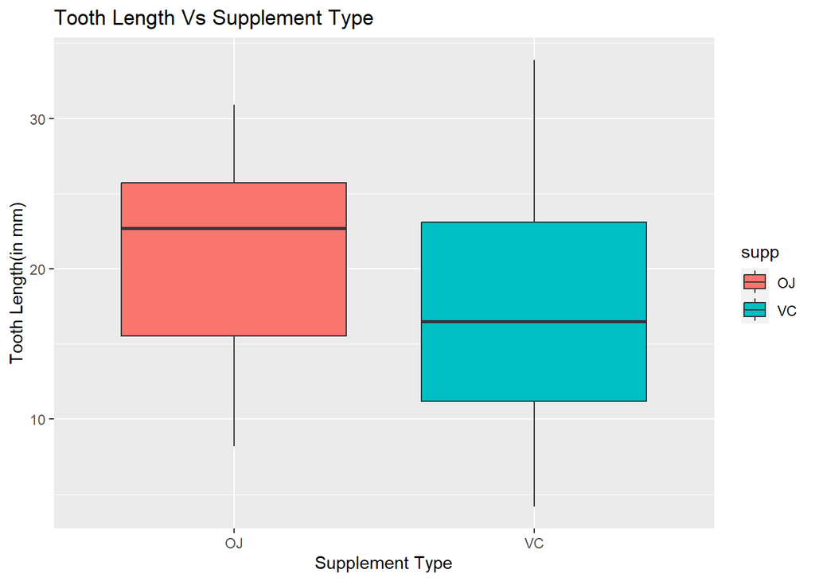

```r
ggplot(data,aes(supp,len))+geom_boxplot(aes(fill=supp))+xlab('Supplement Type')+
  ylab('Tooth Length(in mm)')+labs(title="Tooth Length Vs Supplement Type")
```

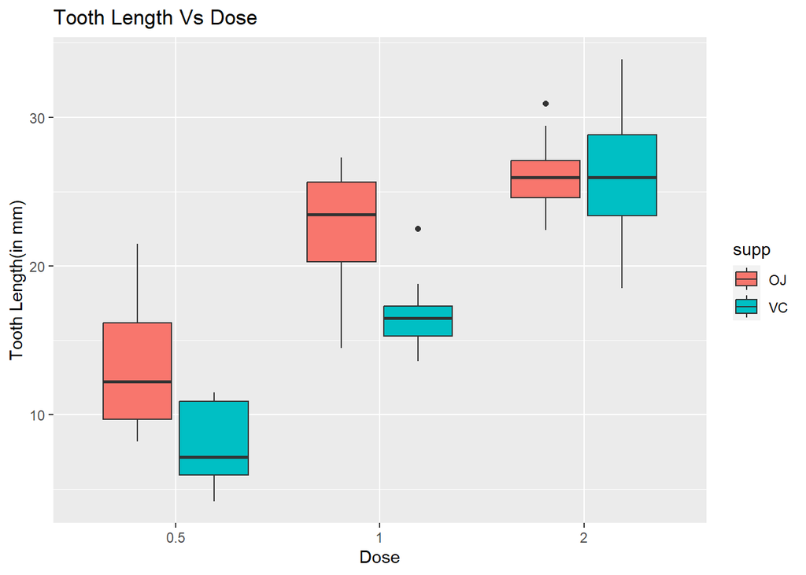

```r
ggplot(data,aes(factor(dose),len))+geom_boxplot(aes(fill=supp))+xlab('Dose')+ylab('Tooth Length(in mm)')+labs(title="Tooth Length Vs Dose")
```

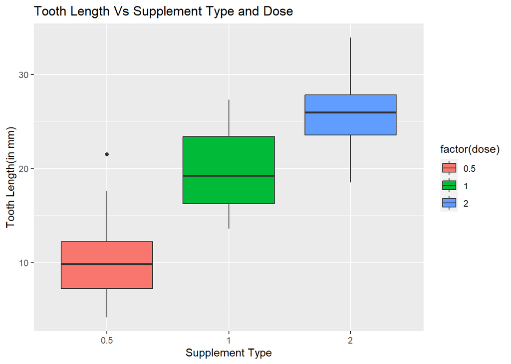

```r
ggplot(data,aes(factor(dose),len))+geom_boxplot(aes(fill=factor(dose)))+xlab('Supplement Type')+
  ylab('Tooth Length(in mm)')+labs(title="Tooth Length Vs Supplement Type and Dose")
```

Is Tooth Length depends on the amount/dose of supplements Vitamin C?

```r
dose_VC_1<- subset(data, supp == 'VC' & dose %in% c(0.5, 1.))
dose_VC_2<- subset(data, supp == 'VC' & dose %in% c(0.5, 2.))
dose_VC_3<- subset(data, supp == 'VC' & dose %in% c(1., 2.))

t.test(len~dose, data=dose_VC_1, var.equal=FALSE, paired=FALSE)
```

```
##
##  Welch Two Sample t-test
##
## data:  len by dose
## t = -7.4634, df = 17.862, p-value = 6.811e-07
## alternative hypothesis: true difference in means between group 0.5 and group 1 is not equal to 0
## 95 percent confidence interval:
##  -11.265712  -6.314288
## sample estimates:
## mean in group 0.5   mean in group 1
##              7.98             16.77
```

```r
t.test(len~dose, data=dose_VC_2, var.equal=FALSE, paired=FALSE)
```

```
##
##  Welch Two Sample t-test
##
## data:  len by dose
## t = -10.388, df = 14.327, p-value = 4.682e-08
## alternative hypothesis: true difference in means between group 0.5 and group 2 is not equal to 0
## 95 percent confidence interval:
##  -21.90151 -14.41849
## sample estimates:
## mean in group 0.5   mean in group 2
##              7.98             26.14
```

```r
t.test(len~dose, data=dose_VC_3, var.equal=FALSE, paired=FALSE)
```

```
##
##  Welch Two Sample t-test
##
## data:  len by dose
## t = -5.4698, df = 13.6, p-value = 9.156e-05
## alternative hypothesis: true difference in means between group 1 and group 2 is not equal to 0
## 95 percent confidence interval:
##  -13.054267  -5.685733
## sample estimates:
## mean in group 1 mean in group 2
##           16.77           26.14
```

For rejecting the null hypothesis p-value should be less than 0.05 which is the 5% significance level. The p-value for all three tests is less then 0.05. Hence, the null hypothesis can be rejected and it suggests that there is a correlation exists between tooth length and supplement amount of “Vitamin C”.

### 2.2. Hypothesis 2

Is Tooth Length depends on the amount/dose of supplements Orange Juice?

```r
dose_OJ_1<- subset(data, supp == 'OJ' & dose %in% c(0.5, 1.0))
dose_OJ_2<- subset(data, supp == 'OJ' & dose %in% c(0.5, 2.))
dose_OJ_3<- subset(data, supp == 'OJ' & dose %in% c(1., 2.))

t.test(len~dose, data=dose_OJ_1, var.equal=FALSE, paired=FALSE)
```

```
##
##  Welch Two Sample t-test
##
## data:  len by dose
## t = -5.0486, df = 17.698, p-value = 8.785e-05
## alternative hypothesis: true difference in means between group 0.5 and group 1 is not equal to 0
## 95 percent confidence interval:
##  -13.415634  -5.524366
## sample estimates:
## mean in group 0.5   mean in group 1
##             13.23             22.70
```

```r
t.test(len~dose, data=dose_OJ_2, var.equal=FALSE, paired=FALSE)
```

```
##
##  Welch Two Sample t-test
##
## data:  len by dose
## t = -7.817, df = 14.668, p-value = 1.324e-06
## alternative hypothesis: true difference in means between group 0.5 and group 2 is not equal to 0
## 95 percent confidence interval:
##  -16.335241  -9.324759
## sample estimates:
## mean in group 0.5   mean in group 2
##             13.23             26.06
```

```r
t.test(len~dose, data=dose_OJ_3, var.equal=FALSE, paired=FALSE)
```

```
##
##  Welch Two Sample t-test
##
## data:  len by dose
## t = -2.2478, df = 15.842, p-value = 0.0392
## alternative hypothesis: true difference in means between group 1 and group 2 is not equal to 0
## 95 percent confidence interval:
##  -6.5314425 -0.1885575
## sample estimates:
## mean in group 1 mean in group 2
##           22.70           26.06
```

Similarly, The P-values in the Hypothesis 2’s tests is less than 0.05. Hence, the null hypothesis can be rejected and it suggests that there is a correlation exists between tooth length and supplement amount of “Orange Juice”.

### 2.3. Hypothesis 3

Is Tooth Length depends on just supplement Type?

```r
df<-data
t.test(len~supp, data=df, var.equal=FALSE, paired=FALSE)
```

```
##
##  Welch Two Sample t-test
##
## data:  len by supp
## t = 1.9153, df = 55.309, p-value = 0.06063
## alternative hypothesis: true difference in means between group OJ and group VC is not equal to 0
## 95 percent confidence interval:
##  -0.1710156  7.5710156
## sample estimates:
## mean in group OJ mean in group VC
##         20.66333         16.96333
```

### 2.4. Hypothesis 4

is Tooth Length depends on specific dose amount?

```r
dose_5<-subset(data, dose %in% c(0.5))
dose_1<-subset(data, dose %in% c(1.))
dose_2<-subset(data, dose %in% c(2.))
t.test(len~supp,data=dose_5,var.equals=FALSE,paired=FALSE)
```

```
##
##  Welch Two Sample t-test
##
## data:  len by supp
## t = 3.1697, df = 14.969, p-value = 0.006359
## alternative hypothesis: true difference in means between group OJ and group VC is not equal to 0
## 95 percent confidence interval:
##  1.719057 8.780943
## sample estimates:
## mean in group OJ mean in group VC
##            13.23             7.98
```

```r
t.test(len~supp,data=dose_1,var.equals=FALSE,paired=FALSE)
```

```
##
##  Welch Two Sample t-test
##
## data:  len by supp
## t = 4.0328, df = 15.358, p-value = 0.001038
## alternative hypothesis: true difference in means between group OJ and group VC is not equal to 0
## 95 percent confidence interval:
##  2.802148 9.057852
## sample estimates:
## mean in group OJ mean in group VC
##            22.70            16.77
```

```r
t.test(len~supp,data=dose_2,var.equals=FALSE,paired=FALSE)
```

```
##
##  Welch Two Sample t-test
##
## data:  len by supp
## t = -0.046136, df = 14.04, p-value = 0.9639
## alternative hypothesis: true difference in means between group OJ and group VC is not equal to 0
## 95 percent confidence interval:
##  -3.79807  3.63807
## sample estimates:
## mean in group OJ mean in group VC
##            26.06            26.14
```

The P-value for dose amount of 0.5mg & 1mg can be rejected. Hence, the tooth length can vary with these dose levels.However, The P-value for 2.0mg is 0.9639 that means the null hypothesis can not be rejected.